```r
rm(list = ls(all = TRUE))
#Do not delete this!
#It clears all variables to ensure reproducibility
```

[figure not shown]

**The dataset is about the houses found in a given California district and some summary stats about them based on the 1990 census data.**

# Setup

```r
library(INLA)
housing<-read.csv("housing.csv")
#removing rows with NA's, there are only a few of these
housing=housing[complete.cases(housing), ]
#creating a new covariate
housing$average_bed_rooms=housing$total_bedrooms/housing$households
head(housing)
```

|  | longitude | latitude | housing_median_age | total_rooms | total_bedrooms | population | households | median_income | median_house_value | ocean_proximity | average_bed_rooms |
| --- | --- | --- | --- | --- | --- | --- | --- | --- | --- | --- | --- |
| 1 | -122.23 | 37.88 | 41 | 880 | 129 | 322 | 126 | 8.3252 | 452600 | NEAR BAY | 1.0238095 |
| 2 | -122.22 | 37.86 | 21 | 7099 | 1106 | 2401 | 1138 | 8.3014 | 358500 | NEAR BAY | 0.9718805 |
| 3 | -122.24 | 37.85 | 52 | 1467 | 190 | 496 | 177 | 7.2574 | 352100 | NEAR BAY | 1.0734463 |
| 4 | -122.25 | 37.85 | 52 | 1274 | 235 | 558 | 219 | 5.6431 | 341300 | NEAR BAY | 1.0730594 |
| 5 | -122.25 | 37.85 | 52 | 1627 | 280 | 565 | 259 | 3.8462 | 342200 | NEAR BAY | 1.0810811 |
| 6 | -122.25 | 37.85 | 52 | 919 | 213 | 413 | 193 | 4.0368 | 269700 | NEAR BAY | 1.1036269 |

**The covariates available from the data are as follows:**

- **longitude**
- **latitude**
- **housing_median_age (median age of houses in district)**
- **total_rooms (total rooms in all houses in district)**
- **total_bedrooms (total bedrooms in all houses in district)**
- **population (population of district)**
- **households (number of households in district)**
- **median_income (median income in district)**
- **median_house_value (median house value in district)**
- **ocean_proximity (categorical covariate about proximity of district to ocean)**
- **average_bed_rooms (average number of bedrooms of houses in district).**

```r
# We split the original dataset into two parts, training and test
housing.training<-housing[seq(from=1,to=nrow(housing),by=2), ]
housing.test<-housing[seq(from=2,to=nrow(housing),by=2), ]

set.seed(1)
# sample <- sample(c(TRUE, FALSE), nrow(iris), replace=TRUE, prob=c(0.7,0.3))
# housing.training <- housing[sample, ]
# housing.test <- housing[!sample, ]
```

```r
# Create a function conducting data preprocessing
preprocess_data <- function(data) {
# Log transformation of median housing value
data$log_med_housing_value <- log(data$median_house_value)

# Scaling numerical features
data$longitude.scaled <- scale(data$longitude)
data$latitude.scaled <- scale(data$latitude)
data$housing_median_age.scaled <- scale(data$housing_median_age)
data$log_med_inc.scaled <- scale(log(data$median_income))
data$avg_bedrooms.scaled <- scale(data$average_bed_rooms)

# Generate polynomial features
data$median_age_scaled_2 <- scale((data$housing_median_age)^2)
data$median_age_scaled_3 <- scale((data$housing_median_age)^3)
data$median_age_scaled_4 <- scale((data$housing_median_age)^4)
data$log_med_inc.scaled_2 <- scale((log(data$median_income))^2)
data$log_med_inc.scaled_3 <- scale((log(data$median_income))^3)
data$log_med_inc.scaled_4 <- scale((log(data$median_income))^4)

# Generate the interaction housing_median_age*log(median_income),
data$int_med_age_log_med_inc <- scale(data$housing_median_age*(log(data$median_income)))

# One-hot encoding for ocean proximity
ocean_prox_df <- as.data.frame(model.matrix(~ ocean_proximity - 1, data = data))
names(ocean_prox_df) <- c("ocean_prox_less1H", "ocean_prox_inland", "ocean_prox_island", "ocean_prox_near_bay", "ocean_prox_near_ocean")
data <- cbind(data, ocean_prox_df)

return(data)
}

# Call the function on your dataset
housing.training <- preprocess_data(housing.training)
```

# Simple Bayesian Linear Regression

**We try to fit a Bayesian Linear regression model in INLA (with Gaussian likelihood) using the housing.training dataset such that the response variable is the log(median_house_value) and the covariates in the model are:**

- **longitude**
- **latitude**
- **housing_median_age**
- **log(median_income)**
- **ocean_proximity**
- **average_bed_rooms.**

**We used scaled versions of all non-categorical covariates to ensure numerical stability (limiting the range of covariates ensures all covariates are comparable on the same scale) and interpretability of our priors.**

```r
# Fitting the Bayesian Linear Regression
# Utilize uninformative priors
prior.beta <- list(mean.intercept = 0, prec.intercept = 1/100, mean = 0, prec = 1/100)

# Fit the model
m1 <- inla(formula = log_med_housing_value ~ longitude.scaled+latitude.scaled+housing_median_age.scaled+log_med_inc.scaled+ocean_proximity+avg_bedrooms.scaled, family="gaussian", data=housing.training, control.fixed = prior.beta, control.predictor = list(compute = TRUE), control.compute = list(dic=T,cpo=T,waic=T, config=TRUE))
summary(m1)
```

```
## Time used:
##     Pre = 2.36, Running = 2.96, Post = 0.44, Total = 5.76
## Fixed effects:
##                             mean    sd 0.025quant 0.5quant 0.975quant   mode
## (Intercept)               12.185 0.006     12.174   12.185     12.197 12.185
## longitude.scaled          -0.313 0.014     -0.341   -0.313     -0.285 -0.313
## latitude.scaled           -0.324 0.015     -0.354   -0.324     -0.295 -0.324
## housing_median_age.scaled  0.028 0.004      0.020    0.028      0.035  0.028
## log_med_inc.scaled         0.322 0.004      0.315    0.322      0.329  0.322
## ocean_proximityINLAND     -0.310 0.012     -0.334   -0.310     -0.286 -0.310
## ocean_proximityISLAND      0.709 0.241      0.236    0.709      1.182  0.709
## ocean_proximityNEAR BAY   -0.005 0.013     -0.031   -0.005      0.021 -0.005
## ocean_proximityNEAR OCEAN -0.014 0.011     -0.036   -0.014      0.007 -0.014
## avg_bedrooms.scaled        0.033 0.003      0.026    0.033      0.039  0.033
##                           kld
## (Intercept)                 0
## longitude.scaled            0
## latitude.scaled             0
## housing_median_age.scaled   0
## log_med_inc.scaled          0
## ocean_proximityINLAND       0
## ocean_proximityISLAND       0
## ocean_proximityNEAR BAY     0
## ocean_proximityNEAR OCEAN   0
## avg_bedrooms.scaled         0
##
## Model hyperparameters:
##                                         mean    sd 0.025quant 0.5quant
## Precision for the Gaussian observations 8.61 0.121       8.38     8.61
##                                         0.975quant mode
## Precision for the Gaussian observations       8.85 8.61
##
## Deviance Information Criterion (DIC) ...............: 7001.28
## Deviance Information Criterion (DIC, saturated) ....: 10220.11
## Effective number of parameters .....................: 6.06
##
## Watanabe-Akaike information criterion (WAIC) ...: 7059.85
## Effective number of parameters .................: 40.94
##
## Marginal log-Likelihood:  -3577.23
## CPO, PIT is computed
## Posterior summaries for the linear predictor and the fitted values are computed
## (Posterior marginals needs also 'control.compute=list(return.marginals.predictor=TRUE)')
```

We compute goodness of fit measures such as the deviance information criterion (DIC), negative logarithm of th survival conditional predictve ordinate (NLSCPO: basically predictive performance of the model when leaving one data point out of the model) and the Watanabe Akaike Information Criterion (WAIC).

```r
cat("n1scpo:", -sum(log(m1$cpo$cpo)), "\n")
```

```
## n1scpo: 3512.786
```

```r
cat("dic:", m1$dic$dic, "\n")
```

```
## dic: 7001.285
```

```r
cat("waic:", m1$waic$waic)
```

```
## waic: 7059.854
```

Perform sensitivity check of our results from changing the priors.

```r
# Conduct sensitivity analysis
prior.beta.sens <- list(mean.intercept = 0, prec.intercept = 1/1000, mean = 0, prec = 1/1000)

# Fit the model
m1.sens <- inla(formula = log_med_housing_value ~ longitude.scaled+latitude.scaled+housing_median_age.scaled+log_med_inc.scaled+ocean_proximity+avg_bedrooms.scaled, family="gaussian", data=housing.training, control.fixed = prior.beta.sens, control.predictor = list(compute = TRUE), control.compute = list(dic=T,cpo=T,waic=T, config=TRUE))
summary(m1.sens)
```

```
## Time used:
##     Pre = 1.97, Running = 2.61, Post = 0.169, Total = 4.75
## Fixed effects:
##                             mean    sd 0.025quant 0.5quant 0.975quant   mode
## (Intercept)               12.185 0.006     12.174   12.185     12.197 12.185
## longitude.scaled          -0.313 0.014     -0.341   -0.313     -0.285 -0.313
## latitude.scaled           -0.324 0.015     -0.354   -0.324     -0.295 -0.324
## housing_median_age.scaled  0.028 0.004      0.020    0.028      0.035  0.028
## log_med_inc.scaled         0.322 0.004      0.315    0.322      0.329  0.322
## ocean_proximityINLAND     -0.310 0.012     -0.334   -0.310     -0.286 -0.310
## ocean_proximityISLAND      0.710 0.241      0.237    0.710      1.183  0.710
## ocean_proximityNEAR BAY   -0.005 0.013     -0.031   -0.005      0.021 -0.005
## ocean_proximityNEAR OCEAN -0.014 0.011     -0.036   -0.014      0.007 -0.014
## avg_bedrooms.scaled        0.033 0.003      0.026    0.033      0.039  0.033
##                           kld
## (Intercept)                 0
## longitude.scaled            0
## latitude.scaled             0
## housing_median_age.scaled   0
## log_med_inc.scaled          0
## ocean_proximityINLAND       0
## ocean_proximityISLAND       0
## ocean_proximityNEAR BAY     0
## ocean_proximityNEAR OCEAN   0
## avg_bedrooms.scaled         0
##
## Model hyperparameters:
##                                         mean    sd 0.025quant 0.5quant
## Precision for the Gaussian observations 8.61 0.121       8.38     8.61
##                                         0.975quant mode
## Precision for the Gaussian observations       8.85 8.61
##
## Deviance Information Criterion (DIC) ...............: 7001.29
## Deviance Information Criterion (DIC, saturated) ....: 10220.11
## Effective number of parameters .....................: 6.07
##
## Watanabe-Akaike information criterion (WAIC) ...: 7059.85
## Effective number of parameters .................: 40.94
##
## Marginal log-Likelihood:  -3588.07
## CPO, PIT is computed
## Posterior summaries for the linear predictor and the fitted values are computed
## (Posterior marginals needs also 'control.compute=list(return.marginals.predictor=TRUE)')
```

```r
cat("n1scpo for sensitivity test:", -sum(log(m1.sens$cpo$cpo)), "\n")
```

```
## n1scpo for sensitivity test: 3512.787
```

```r
cat("dic for sensitivity test:", m1.sens$dic$dic, "\n")
```

```
## dic for sensitivity test: 7001.287
```

```r
cat("waic for sensitivity test:", m1.sens$waic$waic)
```

```
## waic for sensitivity test: 7059.854
```

We can see that the coefficients do not change by a significant amount after running the INLA model again with different hyperparameters (namely a prior with lower precision/higher variance, reflecting an increase in our uncertainty with regards to the priors). This suggests that the model is not very sensitive to changes in the hyperparameters.

**Explanation:**

| Coefficient | Interpretation |
| --- | --- |
| intercept | On average, houses located less than an hour from the ocean show an increase of 12.185 in the log median house value. |
| longitude.scaled | A one standard deviation increase in the scaled longitude would result in a decrease in the log median house value by approximately 0.313 |
| latitude.scaled | A one standard deviation increase in the scaled latitude would result in a decrease in the log median house value by approximately 0.324 |
| housing_median_age.scaled | A one standard deviation increase in the scaled median housing age would result in an increase in the log median house value by approximately 0.028 |
| log_med_inc.scaled | A one standard deviation increase in the scaled log median income would result in an increase in the log median house value by approximately 0.322 |
| ocean_proximityINLAND | On average, houses located inland show a decrease of 0.310 in the log median house value. |
| ocean_proximityISLAND | On average, houses located on an island show an increase in the log median house value by 0.710. |
| ocean_proximityNEAR BAY | On average, houses located near a bay show a decrease of 0.005 in the log median house value. |
| ocean_proximityNEAR OCEAN | On average, houses located near the ocean show a decrease of 0.014 in the log median house value. |
| avg_bedrooms.scaled | A one standard deviation increase in the scaled average number of bedrooms would result in an increase in the log median house value by approximately 0.033 |

# Random effects

**Lets improve the model above by including a random walk 1 (rw1) random effect model for the housing_median_age, and an autoregressive 1 (ar1) random effect model for log(median_income).**

```r
# Utilize uninformative priors
prior.beta <- list(mean.intercept = 0, prec.intercept = 1/100, mean = 0, prec = 1/100)

# Fit the model with rw1 and ar1 effect
# Do we need to add housing_median_age.scaled on top of it being a rw1?
m2 <- inla(formula = log_med_housing_value ~ longitude.scaled+latitude.scaled+f(housing_median_age.scaled, model="rw1")+f(log_med_inc.scaled, model="ar1")+ocean_proximity+avg_bedrooms.scaled, family="gaussian", data=housing.training, control.fixed=prior.beta,control.predictor = list(compute = TRUE), control.compute = list(dic=T,cpo=T,waic=T, config=TRUE))

summary(m2)
```

```
## Time used:
##     Pre = 2.91, Running = 22.2, Post = 1.14, Total = 26.2
## Fixed effects:
##                             mean    sd 0.025quant 0.5quant 0.975quant   mode
## (Intercept)               12.327 0.314     11.687   12.324     12.980 12.324
## longitude.scaled          -0.295 0.014     -0.322   -0.295     -0.268 -0.295
## latitude.scaled           -0.307 0.015     -0.336   -0.307     -0.279 -0.307
## ocean_proximityINLAND     -0.318 0.012     -0.341   -0.318     -0.295 -0.318
## ocean_proximityISLAND      0.626 0.234      0.168    0.626      1.084  0.626
## ocean_proximityNEAR BAY   -0.039 0.013     -0.065   -0.039     -0.013 -0.039
## ocean_proximityNEAR OCEAN -0.013 0.011     -0.033   -0.013      0.008 -0.013
## avg_bedrooms.scaled        0.029 0.003      0.023    0.029      0.036  0.029
##                           kld
## (Intercept)                 0
## longitude.scaled            0
## latitude.scaled             0
## ocean_proximityINLAND       0
## ocean_proximityISLAND       0
## ocean_proximityNEAR BAY     0
## ocean_proximityNEAR OCEAN   0
## avg_bedrooms.scaled         0
##
## Random effects:
##   Name     Model
##     housing_median_age.scaled RW1 model
##    log_med_inc.scaled AR1 model
##
## Model hyperparameters:
##                                           mean    sd 0.025quant 0.5quant
## Precision for the Gaussian observations   9.27  0.13       9.01     9.27
## Precision for housing_median_age.scaled 128.90 50.00      58.23   119.96
## Precision for log_med_inc.scaled         10.66  6.16       2.70     9.34
## Rho for log_med_inc.scaled                1.00  0.00       1.00     1.00
##                                         0.975quant   mode
## Precision for the Gaussian observations       9.53   9.26
## Precision for housing_median_age.scaled     251.87 103.94
## Precision for log_med_inc.scaled             26.12   6.78
## Rho for log_med_inc.scaled                    1.00   1.00
##
## Deviance Information Criterion (DIC) ...............: 6338.87
## Deviance Information Criterion (DIC, saturated) ....: 10306.45
## Effective number of parameters .....................: 88.78
##
## Watanabe-Akaike information criterion (WAIC) ...: 6360.13
## Effective number of parameters .................: 103.30
##
## Marginal log-Likelihood:  -3355.74
## CPO, PIT is computed
## Posterior summaries for the linear predictor and the fitted values are computed
## (Posterior marginals needs also 'control.compute=list(return.marginals.predictor=TRUE)')
```

We plot the posterior means of the random effects where the x-axis is the covariate value and y-axis the posterior mean of the random effect.

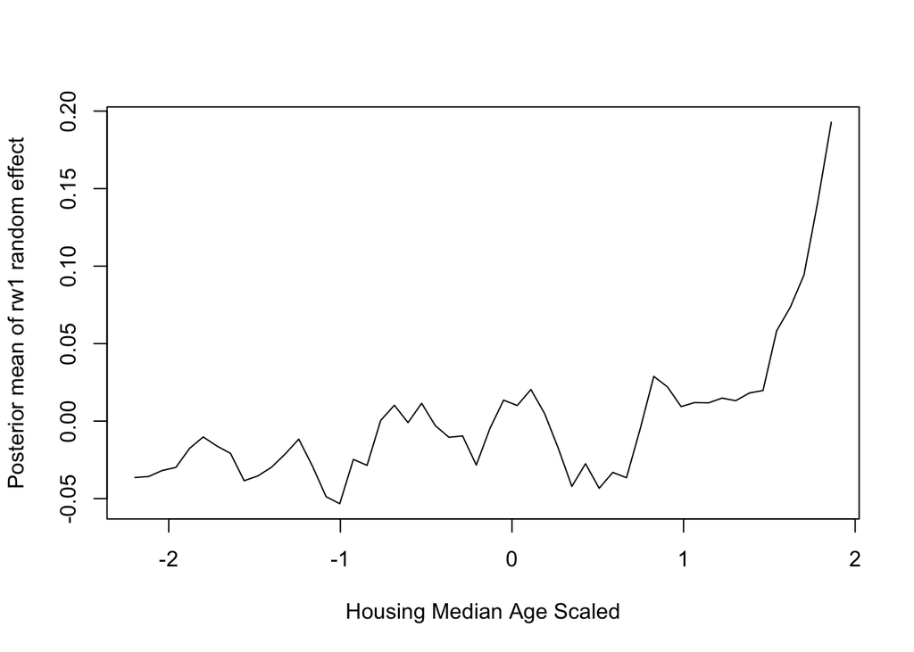

```r
# Plot the posterior mean of the random effects for housing_median_age
# plot(housing.training$housing_median_age.scaled, m2$summary.fitted.values$mean,xlab="Housing Median Age Scaled",ylab="Posterior mean of rw1 random effect")

plot(sort(unique(housing.training$housing_median_age.scaled)), m2$summary.random$housing_median_age.scaled$mean,type="l",xlab="Housing Median Age Scaled",ylab="Posterior mean of rw1 random effect")
```

The plot of the scaled median housing age against the posterior means of the random effects (rw1) demonstrates an upward and downward fluctuation, with the upward trend exploding at greater values of scaled median housing ages.

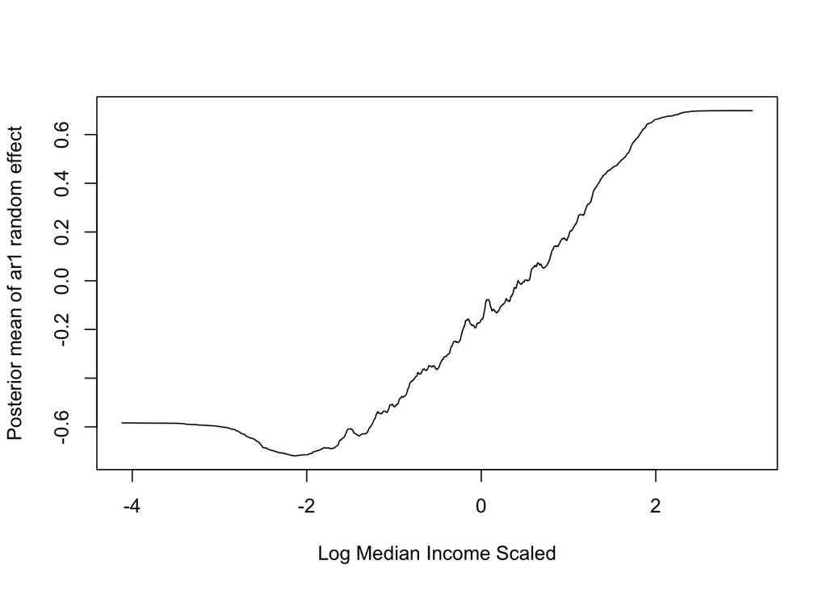

```r
# Plot the posterior mean of the random effects for log median_income
# plot(housing.training$log_med_inc.scaled, m2$summary.fitted.values$mean,xlab="Housing Median Age Scaled",ylab="Posterior mean of rw1 random effect")

plot(sort(unique(housing.training$log_med_inc.scaled)), m2$summary.random$log_med_inc.scaled$mean,type="l",xlab="Log Median Income Scaled",ylab="Posterior mean of ar1 random effect")
```

The plot of the scaled log median income against the posterior means of the random effects (ar1) demonstrates an initial downward pattern followed by an upward trend which appears to decay off near the edge of values of scaled log median income

```r
cat("n1scpo:", -sum(log(m2$cpo$cpo)), "\n")
```

```
## n1scpo: 3178.469
```

```r
cat("dic:", m2$dic$dic, "\n")
```

```
## dic: 6338.869
```

```r
cat("waic:", m2$waic$waic)
```

```
## waic: 6360.127
```

```r
# Sensitivity Analysis
prior.beta.sens <- list(mean.intercept = 0, prec.intercept = 1/1000, mean = 0, prec = 1/1000)

# Fit the model with rw1 and ar1 effect
m2.sens <- inla(formula = log_med_housing_value ~ longitude.scaled+latitude.scaled+f(housing_median_age.scaled, model="rw1")+f(log_med_inc.scaled, model="ar1")+ocean_proximity+avg_bedrooms.scaled, family="gaussian", data=housing.training, control.fixed=prior.beta.sens,control.predictor = list(compute = TRUE), control.compute = list(dic=T,cpo=T,waic=T, config=TRUE))

summary(m2.sens)
```

```
## Time used:
##     Pre = 2.02, Running = 15.4, Post = 1.06, Total = 18.4
## Fixed effects:
##                             mean    sd 0.025quant 0.5quant 0.975quant   mode
## (Intercept)               12.334 0.303     11.720   12.328     12.987 12.330
## longitude.scaled          -0.295 0.014     -0.322   -0.295     -0.268 -0.295
## latitude.scaled           -0.307 0.015     -0.336   -0.307     -0.279 -0.307
## ocean_proximityINLAND     -0.318 0.012     -0.341   -0.318     -0.295 -0.318
## ocean_proximityISLAND      0.627 0.234      0.169    0.627      1.085  0.627
## ocean_proximityNEAR BAY   -0.039 0.013     -0.065   -0.039     -0.013 -0.039
## ocean_proximityNEAR OCEAN -0.013 0.011     -0.033   -0.013      0.008 -0.013
## avg_bedrooms.scaled        0.029 0.003      0.023    0.029      0.036  0.029
##                           kld
## (Intercept)                 0
## longitude.scaled            0
## latitude.scaled             0
## ocean_proximityINLAND       0
## ocean_proximityISLAND       0
## ocean_proximityNEAR BAY     0
## ocean_proximityNEAR OCEAN   0
## avg_bedrooms.scaled         0
##
## Random effects:
##   Name     Model
##     housing_median_age.scaled RW1 model
##    log_med_inc.scaled AR1 model
##
## Model hyperparameters:
##                                           mean    sd 0.025quant 0.5quant
## Precision for the Gaussian observations   9.27  0.13       9.01     9.27
## Precision for housing_median_age.scaled 127.74 47.98      56.55   120.16
## Precision for log_med_inc.scaled         10.23  6.18       1.90     8.95
## Rho for log_med_inc.scaled                1.00  0.00       1.00     1.00
##                                         0.975quant   mode
## Precision for the Gaussian observations       9.53   9.27
## Precision for housing_median_age.scaled     242.55 106.22
## Precision for log_med_inc.scaled             25.00   5.64
## Rho for log_med_inc.scaled                    1.00   1.00
##
## Deviance Information Criterion (DIC) ...............: 6339.25
## Deviance Information Criterion (DIC, saturated) ....: 10308.12
## Effective number of parameters .....................: 89.26
##
## Watanabe-Akaike information criterion (WAIC) ...: 6360.31
## Effective number of parameters .................: 103.58
##
## Marginal log-Likelihood:  -3364.27
## CPO, PIT is computed
## Posterior summaries for the linear predictor and the fitted values are computed
## (Posterior marginals needs also 'control.compute=list(return.marginals.predictor=TRUE)')
```

We can see that the coefficients do not change by a significant amount after running the INLA model again with different hyperparameters (namely a prior with lower precision/higher variance, reflecting an increase in our uncertainty with regards to the priors). This suggests that the model is not very sensitive to changes in the hyperparameters.

**Explanation:**

[output not shown]

# Spatial Random Effects for Location

**Let us improve our model by using a spatial random effects model for the location by creating a Bayesian regression model in inlabru with Gaussian likelihood. The fixed effects in the model are as follows using scaled versions of non-categorical covariates:**

- **longitude**
- **latitude**
- **housing_median_age**
- $(housing\_median\_age)^2$
- $(housing\_median\_age)^3$
- $(housing\_median\_age)^4$
- **log(median_income)**
- $(\log(median\_income))^2$
- $(\log(median\_income))^3$
- $(\log(median\_income))^4$
- **housing_median_age*log(median_income)**
- **ocean_proximity**
- **average_bed_rooms**

**We can include a spatial random effect by creating a spde2 random effect for the location (longitude, latitude), with Matern covariance.**

```r
library(inlabru)
library(sf)
library(splancs)
```

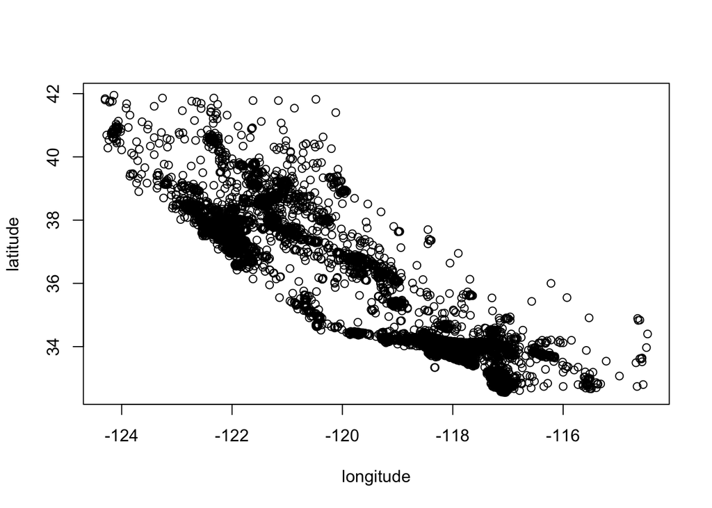

```r
library(gridExtra)
library(lattice)

# Define the spatial area as a matrix
area <- as.matrix(housing.training[,c("longitude", "latitude")])
plot(area)
```

```r
# Create the prediction domain by defining boundaries around the spatial data points. We use the parameters convex and concave to control how the boundary is fit around our data points (coordinates)

# convex (larger/smaller value results in a smoother/rougher boundary)
# concave (larger value allows the boundary to cut into areas with fewer points, making it more flexible, a high value would result in boundaries that are entirely separate from each other)
# Allow convex and concave to be negative to follow the data distribution more precisely
prdomain <- inla.nonconvex.hull(area,
  convex = -0.03, concave = -0.05,
  resolution = c(100, 100))

# Create the mesh over the domain. Max.edge specifies the maximum edge lengths for the triangles (the first argument 0.45 specifies the lengths for the inner extension and the second for the outer), influencing mesh resolution and smoothness. Cutoff avoids building too many triangles at regions with lots of data points
loc.mesh <- inla.mesh.2d(boundary = prdomain, max.edge = c(0.45, 1), cutoff = 0.2)

# Create dataframe containing the locations
Locations = data.frame(easting=housing.training$longitude, northing=housing.training$latitude)

# Matern correlation, defining the prior distributions for the range rho and the standard deviation sigma.
# the argument for range states that there is a 50% probability that the range is larger than or equal to 1 unit of the spatial data (e.g., 1km)
# the argument for sigma states that there is a 10% probability that the strength of the spatial random effect (spatial variability) is greater than or equal to 12
loc.spde = inla.spde2.pcmatern(mesh = loc.mesh,
           prior.range = c(1, 0.5),
           prior.sigma = c(12, 0.1))

# Convert the locations dataframe into a sf object by assigning spatial geometry to each data point
housing.training$geometry <- sf::st_as_sf(Locations, coords = c("easting", "northing"))$geometry

# Specify the formula with ocean_prox_near_ocean as reference category
cmp <- log_med_housing_value ~ floc(geometry, model = loc.spde) + longitude.scaled + latitude.scaled + housing_median_age.scaled + median_age_scaled_2 + median_age_scaled_3 + median_age_scaled_4 + log_med_inc.scaled + log_med_inc.scaled_2 + log_med_inc.scaled_3 + log_med_inc.scaled_4 + int_med_age_log_med_inc + ocean_prox_inland + ocean_prox_island + ocean_prox_near_bay + ocean_prox_near_ocean + avg_bedrooms.scaled + Intercept(1)

# samplers=prdomain and domain arguments restrict the model to the spatial domain and the mesh
m3.bru <- bru(cmp, data=housing.training, family="gaussian", samplers=prdomain,
              domain = list(coordinates = loc.mesh),
              options=list(control.inla=list(tolerance=1e-10),
                           control.compute=list(cpo=T,dic=T,waic=T)))

summary(m3.bru)
```

```
## inlabru version: 2.11.1
## INLA version: 24.06.27
## Components:
## floc: main = spde(geometry), group = exchangeable(1L), replicate = iid(1L)
## longitude.scaled: main = linear(longitude.scaled), group = exchangeable(1L), replicate = iid(1L)
## latitude.scaled: main = linear(latitude.scaled), group = exchangeable(1L), replicate = iid(1L)
## housing_median_age.scaled: main = linear(housing_median_age.scaled), group = exchangeable(1L), replicate = iid(1L)
## median_age_scaled_2: main = linear(median_age_scaled_2), group = exchangeable(1L), replicate = iid(1L)
## median_age_scaled_3: main = linear(median_age_scaled_3), group = exchangeable(1L), replicate = iid(1L)
## median_age_scaled_4: main = linear(median_age_scaled_4), group = exchangeable(1L), replicate = iid(1L)
## log_med_inc.scaled: main = linear(log_med_inc.scaled), group = exchangeable(1L), replicate = iid(1L)
## log_med_inc.scaled_2: main = linear(log_med_inc.scaled_2), group = exchangeable(1L), replicate = iid(1L)
## log_med_inc.scaled_3: main = linear(log_med_inc.scaled_3), group = exchangeable(1L), replicate = iid(1L)
## log_med_inc.scaled_4: main = linear(log_med_inc.scaled_4), group = exchangeable(1L), replicate = iid(1L)
## int_med_age_log_med_inc: main = linear(int_med_age_log_med_inc), group = exchangeable(1L), replicate = iid(1L)
## ocean_prox_inland: main = linear(ocean_prox_inland), group = exchangeable(1L), replicate = iid(1L)
## ocean_prox_island: main = linear(ocean_prox_island), group = exchangeable(1L), replicate = iid(1L)
## ocean_prox_near_bay: main = linear(ocean_prox_near_bay), group = exchangeable(1L), replicate = iid(1L)
## ocean_prox_near_ocean: main = linear(ocean_prox_near_ocean), group = exchangeable(1L), replicate = iid(1L)
## avg_bedrooms.scaled: main = linear(avg_bedrooms.scaled), group = exchangeable(1L), replicate = iid(1L)
## Intercept: main = linear(1), group = exchangeable(1L), replicate = iid(1L)
## Likelihoods:
##   Family: 'gaussian'
##     Data class: 'data.frame'
##     Predictor: log_med_housing_value ~ .
## Time used:
##     Pre = 2.48, Running = 7.91, Post = 0.316, Total = 10.7
## Fixed effects:
##                             mean    sd 0.025quant 0.5quant 0.975quant   mode
## longitude.scaled          -0.361 0.071     -0.500   -0.361     -0.220 -0.361
## latitude.scaled           -0.366 0.072     -0.508   -0.367     -0.223 -0.367
## housing_median_age.scaled -0.485 0.080     -0.643   -0.485     -0.328 -0.485
## median_age_scaled_2        1.889 0.311      1.279    1.889      2.499  1.889
## median_age_scaled_3       -2.933 0.421     -3.759   -2.933     -2.107 -2.933
## median_age_scaled_4        1.478 0.189      1.107    1.478      1.850  1.478
## log_med_inc.scaled        -0.126 0.019     -0.164   -0.126     -0.089 -0.126
## log_med_inc.scaled_2       0.480 0.072      0.340    0.480      0.621  0.480
## log_med_inc.scaled_3       0.063 0.110     -0.153    0.063      0.278  0.063
## log_med_inc.scaled_4      -0.207 0.055     -0.314   -0.207     -0.100 -0.207
## int_med_age_log_med_inc    0.070 0.010      0.051    0.070      0.089  0.070
```

[output cut: 35 more lines]

```
## Precision for the Gaussian observations     14.803 14.372
## Range for floc                               1.197  0.913
## Stdev for floc                               0.431  0.371
##
## Deviance Information Criterion (DIC) ...............: 2010.84
## Deviance Information Criterion (DIC, saturated) ....: 10469.88
## Effective number of parameters .....................: 254.01
##
## Watanabe-Akaike information criterion (WAIC) ...: 1988.27
## Effective number of parameters .................: 228.43
##
## Marginal log-Likelihood:  -1329.45
## CPO, PIT is computed
## Posterior summaries for the linear predictor and the fitted values are computed
## (Posterior marginals needs also 'control.compute=list(return.marginals.predictor=TRUE)')
```

Plot the posterior mean of the spatial random effect in terms of the location.

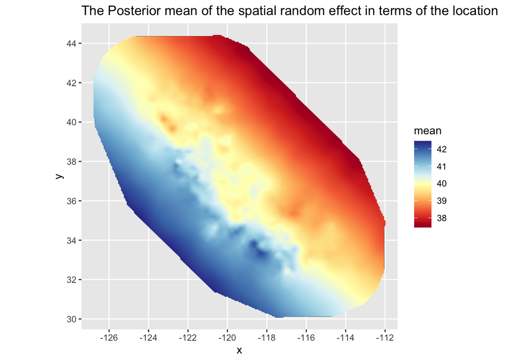

```r
# Plot the posterior mean of the spatial random effect in terms of the location
library(fmesher)
library(ggplot2)
library(tidyverse)
library(RColorBrewer)
library(ggregplot)
library(fmesher)
library(sp)

pix <- fm_pixels(loc.mesh, dims = c(200, 200), format = "sf")
stpix <- sf::st_coordinates(pix)
pix$latitude.scaled <- stpix[,2]
pix$longitude.scaled <- stpix[,1]

pred <- predict(m3.bru, pix, ~ floc+Intercept+longitude.scaled+latitude.scaled)

ggplot() + gg(loc.mesh) + ggtitle("The Posterior mean of the spatial random effect in terms of the location") +
gg(pred, aes(color = mean)) +
scale_color_gradientn(colours=brewer.pal(11, "RdYlBu"),limits=range(pred$mean))
```

According to the plot posterior mean of the spatial random effect in terms of the location, houses that are located close to the ocean tend to be of higher value and houses further inland tend to be lower in value.

```r
# Compute comparative statistics
cat("n1scpo:", -sum(log(m3.bru$cpo$cpo)), "\n")
```

```
## n1scpo: 1017.07
```

```r
cat("dic:", m3.bru$dic$dic, "\n")
```

```
## dic: 2010.838
```

```r
cat("waic:", m3.bru$waic$waic)
```

```
## waic: 1988.273
```

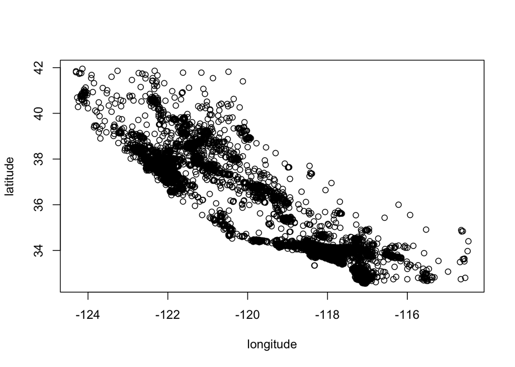

```r
# Sensitivity checks and using a finer mesh
# Create the area
area <- as.matrix(housing.training[,c("longitude", "latitude")])
plot(area)
```

```r
prdomain <- inla.nonconvex.hull(area,
  convex = -0.03, concave = -0.05,
  resolution = c(100, 100))

# Create a finer mesh
loc.mesh.sens <- inla.mesh.2d(boundary = prdomain, max.edge = c(0.1, 1), cutoff = 0.2)

# Create dataframe containing the locations
Locations = data.frame(easting=housing.training$longitude, northing=housing.training$latitude)

# Matern correlation adjusting the prior to have a higher degree of uncertainty
loc.spde.sens = inla.spde2.pcmatern(mesh = loc.mesh.sens,
           prior.range = c(1, 0.5),
           prior.sigma = c(200, 0.1))

housing.training$geometry <- sf::st_as_sf(Locations, coords = c("easting", "northing"))$geometry

# Specify the formula with ocean_prox_near_ocean as reference category
cmp.sens <- log_med_housing_value ~ floc(geometry, model = loc.spde.sens) + longitude.scaled + latitude.scaled + housing_median_age.scaled + median_age_scaled_2 + median_age_scaled_3 + median_age_scaled_4 + log_med_inc.scaled + log_med_inc.scaled_2 + log_med_inc.scaled_3 + log_med_inc.scaled_4 + int_med_age_log_med_inc + ocean_prox_inland + ocean_prox_island + ocean_prox_near_bay + ocean_prox_near_ocean + avg_bedrooms.scaled + Intercept(1)

m3.bru.sens <- bru(cmp, data=housing.training, family="gaussian", samplers=prdomain, domain = list(coordinates = loc.mesh), options=list(control.inla=list(tolerance=1e-10), control.compute=list(cpo=T,dic=T,waic=T)))

summary(m3.bru.sens)
```

```
## inlabru version: 2.11.1
## INLA version: 24.06.27
## Components:
## floc: main = spde(geometry), group = exchangeable(1L), replicate = iid(1L)
## longitude.scaled: main = linear(longitude.scaled), group = exchangeable(1L), replicate = iid(1L)
## latitude.scaled: main = linear(latitude.scaled), group = exchangeable(1L), replicate = iid(1L)
## housing_median_age.scaled: main = linear(housing_median_age.scaled), group = exchangeable(1L), replicate = iid(1L)
## median_age_scaled_2: main = linear(median_age_scaled_2), group = exchangeable(1L), replicate = iid(1L)
## median_age_scaled_3: main = linear(median_age_scaled_3), group = exchangeable(1L), replicate = iid(1L)
## median_age_scaled_4: main = linear(median_age_scaled_4), group = exchangeable(1L), replicate = iid(1L)
## log_med_inc.scaled: main = linear(log_med_inc.scaled), group = exchangeable(1L), replicate = iid(1L)
## log_med_inc.scaled_2: main = linear(log_med_inc.scaled_2), group = exchangeable(1L), replicate = iid(1L)
## log_med_inc.scaled_3: main = linear(log_med_inc.scaled_3), group = exchangeable(1L), replicate = iid(1L)
## log_med_inc.scaled_4: main = linear(log_med_inc.scaled_4), group = exchangeable(1L), replicate = iid(1L)
## int_med_age_log_med_inc: main = linear(int_med_age_log_med_inc), group = exchangeable(1L), replicate = iid(1L)
## ocean_prox_inland: main = linear(ocean_prox_inland), group = exchangeable(1L), replicate = iid(1L)
## ocean_prox_island: main = linear(ocean_prox_island), group = exchangeable(1L), replicate = iid(1L)
## ocean_prox_near_bay: main = linear(ocean_prox_near_bay), group = exchangeable(1L), replicate = iid(1L)
## ocean_prox_near_ocean: main = linear(ocean_prox_near_ocean), group = exchangeable(1L), replicate = iid(1L)
## avg_bedrooms.scaled: main = linear(avg_bedrooms.scaled), group = exchangeable(1L), replicate = iid(1L)
## Intercept: main = linear(1), group = exchangeable(1L), replicate = iid(1L)
## Likelihoods:
##   Family: 'gaussian'
##     Data class: 'data.frame'
##     Predictor: log_med_housing_value ~ .
## Time used:
##     Pre = 3.3, Running = 10.4, Post = 0.357, Total = 14.1
## Fixed effects:
##                             mean    sd 0.025quant 0.5quant 0.975quant   mode
## longitude.scaled          -0.361 0.071     -0.500   -0.361     -0.220 -0.361
## latitude.scaled           -0.366 0.072     -0.508   -0.367     -0.223 -0.367
## housing_median_age.scaled -0.485 0.080     -0.642   -0.485     -0.328 -0.485
## median_age_scaled_2        1.889 0.311      1.279    1.889      2.499  1.889
## median_age_scaled_3       -2.933 0.421     -3.759   -2.933     -2.107 -2.933
## median_age_scaled_4        1.478 0.189      1.107    1.478      1.850  1.478
## log_med_inc.scaled        -0.126 0.019     -0.164   -0.126     -0.089 -0.126
## log_med_inc.scaled_2       0.480 0.072      0.340    0.480      0.621  0.480
## log_med_inc.scaled_3       0.063 0.110     -0.153    0.063      0.278  0.063
## log_med_inc.scaled_4      -0.207 0.055     -0.314   -0.207     -0.100 -0.207
## int_med_age_log_med_inc    0.070 0.010      0.051    0.070      0.089  0.070
```

[output cut: 35 more lines]

```
## Precision for the Gaussian observations     14.796 14.381
## Range for floc                               1.198  0.911
## Stdev for floc                               0.431  0.371
##
## Deviance Information Criterion (DIC) ...............: 2010.83
## Deviance Information Criterion (DIC, saturated) ....: 10473.32
## Effective number of parameters .....................: 254.15
##
## Watanabe-Akaike information criterion (WAIC) ...: 1988.20
## Effective number of parameters .................: 228.53
##
## Marginal log-Likelihood:  -1329.44
## CPO, PIT is computed
## Posterior summaries for the linear predictor and the fitted values are computed
## (Posterior marginals needs also 'control.compute=list(return.marginals.predictor=TRUE)')
```

```r
# Compute comparative statistics
cat("n1scpo:", -sum(log(m3.bru.sens$cpo$cpo)), "\n")
```

```
## n1scpo: 1017.052
```

```r
cat("dic:", m3.bru.sens$dic$dic, "\n")
```

```
## dic: 2010.827
```

```r
cat("waic:", m3.bru.sens$waic$waic)
```

```
## waic: 1988.202
```

**Explanation:**

[output not shown]

# Model Comparison

We compare all our models based on the goodness of fit measures

Model Comparison

[output not shown]

We can see that as we increase the complexity of our model, by incorporating random effects (with a rw1 and ar1 random effects) and then by incorporating polynomial terms, interaction terms and spatial random effects (through the SPDE), all performance metrics improve. Overall, INLA Model 3 have much better performance than the simple Bayesian linear regression model, INLA Model 1 and the Bayesian model with random effects, INLA model 2.

# Predictive Performance

**We will now evaluate the predictive performance of these models by performing two tests for all 3 models.**

**In the first test, we compute the posterior mean of the log(median_house_value) for the districts in the training dataset housing.training. Compute the median absolute difference between the posterior means of the log(median_house_value) and its true values on the training dataset. This can be done by including the posterior means in an array** $v$ **, the true values in an array** $t$**, and computing** $\text{median}(|v-t|)$.

**In the second test, we will evaluate the log(median_house_value) ’s posterior predictive means on the test dataset housing.test. Compute the median absolute difference between the log(median_house_value) ’s posterior predictive mean and its true value on the test dataset.**

```r
# Model 1
m1_diff <- median(abs(m1$summary.fitted.values$mean - housing.training$log_med_housing_value))

cat("Performance of the posterior mean in model 1 of the log median house value against the training dataset:", m1_diff)
```

```
## Performance of the posterior mean in model 1 of the log median house value against the training dataset: 0.2094215
```

```r
# Evaluate the posterior predictive mean on the test dataset by rerunning model 1 but on the test data
housing.test <- preprocess_data(housing.test)

prior.beta <- list(mean.intercept = 0, prec.intercept = 1/100, mean = 0, prec = 1/100)

# Fit the model
m1.test <- inla(formula = log_med_housing_value ~ longitude.scaled+latitude.scaled+housing_median_age.scaled+log_med_inc.scaled+ocean_proximity+avg_bedrooms.scaled, family="gaussian", data=housing.test, control.fixed = prior.beta, control.predictor = list(compute = TRUE), control.compute = list(dic=T,cpo=T,waic=T))

# Evaluate the posterior predictive mean on the test dataset
m1_diff_test <- median(abs(m1.test$summary.fitted.values$mean - housing.test$log_med_housing_value))

cat("Performance of the posterior mean in model 1 of the log median house value against the test dataset:", m1_diff_test)
```

```
## Performance of the posterior mean in model 1 of the log median house value against the test dataset: 0.207546
```

```r
# Model 2
m2_diff <- median(abs(m2$summary.fitted.values$mean - housing.training$log_med_housing_value))

cat("Performance of the posterior mean in model 2 of the log median house value against the training dataset:", m2_diff)
```

```
## Performance of the posterior mean in model 2 of the log median house value against the training dataset: 0.1995993
```

```r
# Evaluate the posterior predictive mean on the test dataset by rerunning model 2 but on the test data
prior.beta <- list(mean.intercept = 0, prec.intercept = 1/100, mean = 0, prec = 1/100)

# Fit the model with rw1 and ar1 effect
# Do we need to add housing_median_age.scaled on top of it being a rw1?
m2.test <- inla(formula = log_med_housing_value ~ longitude.scaled+latitude.scaled+f(housing_median_age.scaled, model="rw1")+f(log_med_inc.scaled, model="ar1")+ocean_proximity+avg_bedrooms.scaled, family="gaussian", data=housing.test, control.fixed=prior.beta,control.predictor = list(compute = TRUE), control.compute = list(dic=T,cpo=T,waic=T))

# Evaluate the posterior predictive mean on the test dataset
m2_diff_test <- median(abs(m2.test$summary.fitted.values$mean - housing.test$log_med_housing_value))

cat("Performance of the posterior mean in model 2 of the log median house value against the test dataset:", m2_diff_test)
```

```
## Performance of the posterior mean in model 2 of the log median house value against the test dataset: 0.1980287
```

```r
# Model 3
m3_diff <- median(abs(m3.bru$summary.fitted.values$mean[1:length(housing.training$log_med_housing_value)] - housing.training$log_med_housing_value))

cat("Performance of the posterior mean in model 3 of the log median house value against the training dataset:", m3_diff)
```

```
## Performance of the posterior mean in model 3 of the log median house value against the training dataset: 0.1507002
```

```r
# Evaluate the posterior predictive mean on the test dataset by rerunning model 3 but on the test data
area.test <- as.matrix(housing.test[,c("longitude", "latitude")])

prdomain.test <- inla.nonconvex.hull(area.test,
  convex = -0.03, concave = -0.05,
  resolution = c(100, 100))

# Create the mesh
loc.mesh.test <- inla.mesh.2d(boundary = prdomain.test, max.edge = c(0.45, 1), cutoff = 0.2)

# Create dataframe containing the locations
Locations.test = data.frame(easting=housing.test$longitude, northing=housing.test$latitude)

# Matern correlation
loc.spde.test = inla.spde2.pcmatern(mesh = loc.mesh.test,
           prior.range = c(1, 0.5),
           prior.sigma = c(12, 0.1))

housing.test$geometry <- sf::st_as_sf(Locations.test, coords = c("easting", "northing"))$geometry

# Specify the formula with ocean_prox_near_ocean as reference category
cmp <- log_med_housing_value ~ floc(geometry, model = loc.spde.test) + longitude.scaled + latitude.scaled + housing_median_age.scaled + median_age_scaled_2 + median_age_scaled_3 + median_age_scaled_4 + log_med_inc.scaled + log_med_inc.scaled_2 + log_med_inc.scaled_3 + log_med_inc.scaled_4 + int_med_age_log_med_inc + ocean_prox_inland + ocean_prox_island + ocean_prox_near_bay + ocean_prox_near_ocean + avg_bedrooms.scaled + Intercept(1)

m3.bru.test <- bru(cmp, data=housing.test, family="gaussian", samplers=prdomain.test, domain = list(coordinates = loc.mesh.test), options=list(control.inla=list(tolerance=1e-10), control.compute=list(cpo=T,dic=T,waic=T)))

# Evaluate the posterior predictive mean on the test dataset
m3_diff_test <- median(abs(m3.bru.test$summary.fitted.values$mean[1:length(housing.test$log_med_housing_value)] - housing.test$log_med_housing_value))

cat("Performance of the posterior mean in model 3 of the log median house value against the test dataset:", m3_diff_test)
```

```
## Performance of the posterior mean in model 3 of the log median house value against the test dataset: 0.147881
```

Median of the absolute difference between the posterior predictive means against the true value

[output not shown]

As we can see, model 3 with the spatial random effects had the lowest prediction error when evaluating the median absolute difference between the posterior predictive mean against the true housing value. Furthermore, we can see that the difference between the performance of model 1 and model 2 is very small, suggesting that including rw1 and ar1 random effects did not result in a significant improvement in the accuracy of the model. The significant outperformance of model 3 compared to models 1 and 2 is expected as the SPDE is able to capture/account for location specific effects on the response (log housing value) which would therefore, produce more accurate predictions.

# Posterior Predictive Checks

**It is essential that we perform posterior predictive checks (using replicates) on all 3 models fitted on the housing.training dataset to ensure our models accurately reflect the characteristics of our data.**

```r
# Create a function to generate replicate data and plot the test functions
require(fBasics)
posterior_samples <- function(model) {

nsamp <- 3000
n <- nrow(housing.training)
housing.samples <- inla.posterior.sample(n=nsamp, result=model)

yrep <- matrix(0,nrow=n,ncol=nsamp)
y <- housing.training$log_med_housing_value
predictor.samples <- inla.posterior.sample.eval(function(...) {Predictor},
housing.samples)

sigma.samples <- 1/sqrt(inla.posterior.sample.eval(function(...) {theta},
housing.samples))

yrep <- matrix(0,nrow=n,ncol=nsamp)

for(row.num in 1:n){
yrep[row.num, ]<- predictor.samples[row.num, ]+rnorm(n=nsamp,mean=0,sd=sigma.samples)
}

yrepmin <- apply(yrep,2,min)
yrepmax <- apply(yrep,2,max)
yrepmedian <- apply(yrep,2,median)
yrepskewness <- apply(yrep,2,skewness)
yrepkurtosis <- apply(yrep,2,kurtosis)

par(mfrow = c(3, 2))  # Set up multiple plots

#Predictive checks using replicated data - minimum
hist(yrepmin,col="gray40", main = "Minimum Values", xlab = "Values", xlim=c(min(yrepmin, min(y)), max(yrepmin, min(y))))
abline(v=min(y),col="red",lwd=2)

#Predictive checks using replicated data - maximum
hist(yrepmax,col="gray40", main = "Maximum Values", xlab = "Values", xlim=c(min(yrepmax, max(y)), max(yrepmax, max(y))))
abline(v=max(y),col="red",lwd=2)

#Predictive checks using replicated data - median
hist(yrepmedian,col="gray40", main = "Median Values", xlab = "Values", xlim=c(min(yrepmedian, median(y)), max(yrepmedian, median(y))))
abline(v=median(y),col="red",lwd=2)

#Predictive checks using replicated data - skewness
hist(yrepskewness,col="gray40", main = "Skewness Values", xlab = "Values", xlim=c(min(yrepskewness, skewness(y)), max(yrepskewness, skewness(y))))
abline(v=skewness(y),col="red",lwd=2)

#Predictive checks using replicated data - kurtosis
hist(yrepkurtosis,col="gray40", main = "Kurtosis Values", xlab = "Values", xlim=c(min(yrepkurtosis, kurtosis(y)), max(yrepkurtosis, kurtosis(y))))
abline(v=kurtosis(y),col="red",lwd=2)
}

# Function for the INLA bru object
posterior_samples_bru <- function(model) {

nsamp <- 3000
n <- nrow(housing.training)
housing.samples <- inla.posterior.sample(n=nsamp, result=model)

yrep <- matrix(0,nrow=n,ncol=nsamp)
y <- housing.training$log_med_housing_value
predictor.samples <- inla.posterior.sample.eval(function(...) {APredictor},
housing.samples)

sigma.samples <- 1/sqrt(inla.posterior.sample.eval(function(...) {theta},
housing.samples))

yrep <- matrix(0,nrow=n,ncol=nsamp)

for(row.num in 1:n){
yrep[row.num, ]<- predictor.samples[row.num, ]+rnorm(n=nsamp,mean=0,sd=sigma.samples)
}

yrepmin <- apply(yrep,2,min)
yrepmax <- apply(yrep,2,max)
yrepmedian <- apply(yrep,2,median)
yrepskewness <- apply(yrep,2,skewness)
yrepkurtosis <- apply(yrep,2,kurtosis)

par(mfrow = c(3, 2))  # Set up multiple plots

#Predictive checks using replicated data - minimum
hist(yrepmin,col="gray40", main = "Minimum Values", xlab = "Values", xlim=c(min(yrepmin, min(y)), max(yrepmin, min(y))))
abline(v=min(y),col="red",lwd=2)

#Predictive checks using replicated data - maximum
hist(yrepmax,col="gray40", main = "Maximum Values", xlab = "Values", xlim=c(min(yrepmax, max(y)), max(yrepmax, max(y))))
abline(v=max(y),col="red",lwd=2)

#Predictive checks using replicated data - median
hist(yrepmedian,col="gray40", main = "Median Values", xlab = "Values", xlim=c(min(yrepmedian, median(y)), max(yrepmedian, median(y))))
abline(v=median(y),col="red",lwd=2)

#Predictive checks using replicated data - skewness
hist(yrepskewness,col="gray40", main = "Skewness Values", xlab = "Values", xlim=c(min(yrepskewness, skewness(y)), max(yrepskewness, skewness(y))))
abline(v=skewness(y),col="red",lwd=2)

#Predictive checks using replicated data - kurtosis
hist(yrepkurtosis,col="gray40", main = "Kurtosis Values", xlab = "Values", xlim=c(min(yrepkurtosis, kurtosis(y)), max(yrepkurtosis, kurtosis(y))))
abline(v=kurtosis(y),col="red",lwd=2)
}
```

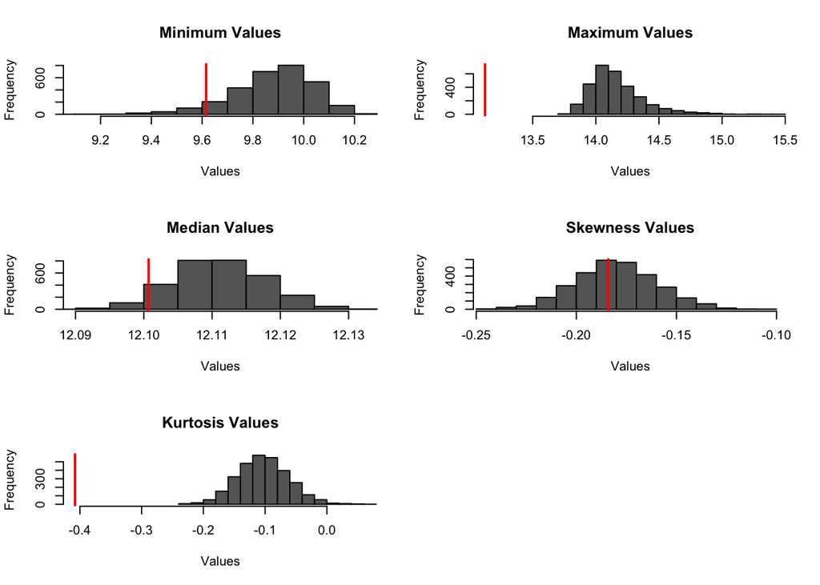

```r
# Posterior predictive checks for model 1
posterior_samples(m1)
```

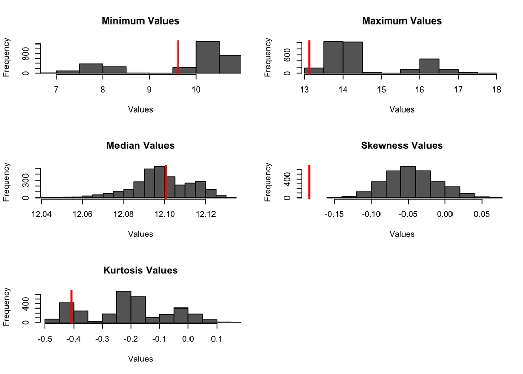

```r
# Posterior predictive checks for model 2
posterior_samples(m2)
```

Does the test function applied on our observed data fall within the test functions applied to the posterior predicted replicates *The test function of the observed data falls on the edge of the range

| Model | Minimum | Maximum | Median | Skewness | Kurtosis |
| --- | --- | --- | --- | --- | --- |
| Model 1 | Yes | No | Yes | Yes | No |
| Model 2 | Yes | Yes* | Yes | No | Yes |
| Model 3 | Yes | No | Yes | No | No |

```r
# Posterior predictive checks for model 3
posterior_samples_bru(m3.bru)
```